# Advanced SQL techniques

Mirko Mälicke

```r
# require the package
if (!("RPostgreSQL" %in% installed.packages())){
  install.packages("RPostgreSQL")
}
if (!("getPass" %in% installed.packages())){
  install.packages("getPass")
}
require(RPostgreSQL)
require(getPass)
```

```r
require(ggplot2)
require(dplyr)
# establish the connection
drv <- dbDriver('PostgreSQL')
con <- dbConnect(drv, host='openhydro.de', port=5432, user=getPass('Provide the user'),
                 password=getPass('Provide the password'), dbname='dwd')
```

```
## Please enter password in TK window (Alt+Tab)
## Please enter password in TK window (Alt+Tab)
```

# 1 Temporarily creating objects

Especially for development and data analysis tasks it is very useful to create temporary results. This saves a lot of time and will keep your database clean as you do not have to remember which objects were only intermediate and can be droped. The SQL language knows the TEMPORARY keyword, which can be used along with CREATE statements. This is most often used on the creation of tables and views. The temporary tables can be used just like persistent tables, but once you close the connection used for creation, the table will automatically be droped. This can save you from a lot of cleanup work.

Some SQL clients open and close a connection on each command issued in order to keep the number of connection small and prevent the user from keeping open connections. You will have to change the settings or the tool in case you want to use temporary object using these tools.

There is a table called *bw_temp_2017b* in the database. This table includes daily meteorological measurements as distributed by the DWD for temperature, rainfall, snowfall and relative humidity. The database table is saved just like it was imorted. The table *data* is a more normalized version of the first one. A temporary table can be useful to extract only the parameters needed from the normalized table. Let’s have a look at it.

```sql
select * from data order by id, date DESC limit 10
```

Displaying records 1 - 10

| id | date | variable_id | value |
| --- | --- | --- | --- |
| 257 | 2016-12-31 | 8 | NA |
| 257 | 2016-12-31 | 4 | 0.0 |
| 257 | 2016-12-31 | 6 | -6.9 |
| 257 | 2016-12-31 | 7 | -1.3 |
| 257 | 2016-12-31 | 3 | 0.0 |
| 257 | 2016-12-31 | 5 | -10.1 |
| 257 | 2016-12-31 | 1 | 0.0 |
| 257 | 2016-12-30 | 1 | 0.0 |
| 257 | 2016-12-30 | 5 | -9.2 |
| 257 | 2016-12-30 | 3 | 0.0 |

As you can see, there are different values for the same day at the same station. The meaning of this value is described in a lookup table joined by the variable id. This structure might feel strange but is very common to save timeseries data. It is performat, flexible and easy to maintain and extend. These advantages come at the tradeoff of a bit more complex structure and hence more complicated queries. But one step after the other. Let’s have a look at the lookup table.

```sql
select * from variables
```

7 records

| id | short | name | unit |
| --- | --- | --- | --- |
| 3 | rskf | type of precipitation | NA |
| 1 | rsk | precipitation | mm |
| 4 | shk_tag | snow height | cm |
| 6 | tmk | mean daily temperature | deg. C |
| 7 | txk | max daily temperature | deg. C |
| 5 | tnk | min daily temperature | deg. C |
| 8 | upm | mean relative humidity | #% |

This is a quite small lookup table, but as you can see we do not have to write the full name of the variable behind every entry in the data table. The brings us way more flexibility in describing the variables. At the end of the day both tables be joined togehter quite easy.

Imagine we only want to use the precipitation values today, we can build a new temporary table as a starting point.

```sql
create temporary table precipitation as
select id, date, value as precipitation from data where variable_id=1
```

```sql
select * from precipitation limit 5
```

5 records

| id | date | precipitation |
| --- | --- | --- |
| 257 | 2012-09-10 | 0.0 |
| 257 | 2012-09-11 | 24.0 |
| 257 | 2012-09-12 | 6.6 |
| 257 | 2012-09-13 | 0.0 |
| 257 | 2012-09-14 | 1.6 |

The next structure we want to use is the view. A view is like a persistant SELECT query that will be rerun each time you try to query the results. It will behave like a dynamic table with the only difference of being not editable. From a performance point of view, a view is not capable of indices, which can make it way slower than a table.  
Let’s create a view of monthly min, max, mean, and count of precipitation.

```sql
create temporary view precipitation_summary as
select id, date_trunc('month', date) as month,
  avg(precipitation) as mean,
  min(case when precipitation > 0.0 then precipitation end) as min,
  max(precipitation) as max,
  sum((precipitation > 0.0)::integer) as "rainy days"
from precipitation
group by id, month
```

```sql
select * from precipitation_summary
```

Displaying records 1 - 10

| id | month | mean | min | max | rainy days |
| --- | --- | --- | --- | --- | --- |
| 257 | 1949-01-01 | 2.4967742 | 0.7 | 26.5 | 14 |
| 257 | 1949-02-01 | 1.2607143 | 0.1 | 9.3 | 11 |
| 257 | 1949-03-01 | 1.3193548 | 0.2 | 10.8 | 12 |
| 257 | 1949-04-01 | 2.3833333 | 0.1 | 12.2 | 15 |
| 257 | 1949-05-01 | 3.0451613 | 0.1 | 15.3 | 21 |
| 257 | 1949-06-01 | 1.1100000 | 0.2 | 17.5 | 8 |
| 257 | 1949-07-01 | 0.3419355 | 0.6 | 5.0 | 5 |
| 257 | 1949-08-01 | 2.6322581 | 0.2 | 27.1 | 10 |
| 257 | 1949-09-01 | 1.7333333 | 0.2 | 14.7 | 12 |
| 257 | 1949-10-01 | 1.9516129 | 0.1 | 27.6 | 11 |

This is a great overview table for doing some in-depth analysis of the precipitation distribution. Once you streamed your results into R, a persistant table or any kind of text-based file, you can just close the database connection and the two tables *precipitation* and *precipitation_summary* will be dropped.

```sql
select month, mean, min, max from precipitation_summary where id=257 order by month ASC
```

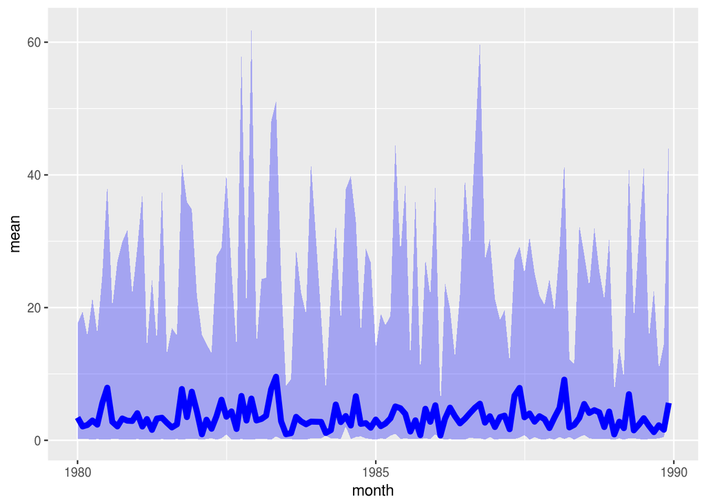

```r
precipitation %>%
  filter(month >= '1980-01-01' & month < '1990-01-01') %>%
  ggplot(aes(x=month, y=mean)) +
    geom_ribbon(aes(ymin=min, ymax=max),fill='blue', alpha=0.3) +
    geom_line(color='blue', size=2)
```

Before you continue, play around with these objects a little bit. You should get a good feeling for whether to use temporary object or not You could for example create another view that holds the exact same information but only for summer rainfalls. This means the date should be in summer and the temperature for example above 18°C.

Now close the connection:

```r
dbDisconnect(con)
```

```
## [1] TRUE
```

Restablish:

```r
# establish the connection
drv <- dbDriver('PostgreSQL')
con <- dbConnect(drv, host='openhydro.de', port=5432, user=getPass('Provide the user'),
                 password=getPass('Provide the password'), dbname='dwd')
```

```
## Please enter password in TK window (Alt+Tab)
## Please enter password in TK window (Alt+Tab)
```

And the tables are gone

```r
'precipitation' %in% dbListTables(con) | 'precipitation_summary' %in% dbListTables(con)
```

```
## [1] FALSE
```

# 2 Joins

## 2.1 chaining Joins

This section will give some more insights on JOINS. It will cover different types of JOINS and how to chain a JOIN. Quite often you will find yourself in a situation, where you have to join a lookup table to a table of interest and this lookup table is itself described by another lookup table. Querying these structures is fairly straightforward as you can just chain joins together. This can be demonstrated by the vegetation_cover table

```sql
select * from stations s
join vegetation_cover vc on st_within(s.geometry, vc.geometry)
join vegetation_cover_description vd on vd.id=vc.description_id
```

Displaying records 1 - 10

| id | name | elevation | geometry | description | discipline_id | hobo_id | influence | id | description_id | geometry | id | name |
| --- | --- | --- | --- | --- | --- | --- | --- | --- | --- | --- | --- | --- |
| 755 | Buchen_Kr_Neckar_Odenwald | 340 | 0101000020E8640000969F6DA1DFEF1F41D4B1E8738EEC5441 | NA | 1 | NA | NA | 659 | 20 | 0103000020E86400000100000013000000790290A22DFA1F415DDC9C67BB…… | 20 | gering bis mittel |
| 3257 | Mergentheim_Bad_Neunkirchen | 250 | 0101000020E86400001BBE72A99CF12041E889991557E85441 | NA | 1 | NA | NA | 1295 | 35 | 0103000020E8640000070000007C000000D62659C72DEF2041EC63B44A75…… | 35 | mittel bis sehr hoch |
| 5906 | Mannheim | 96 | 0101000020E86400007F892ABA1D8C1C41E781933B9AEB5441 | NA | 1 | NA | NA | 1307 | 5 | 0103000020E8640000030000006E000000C896B7636EE51C41E5DEFA5C6F…… | 5 | sehr gering bis gering |
| 3761 | Oehringen | 276 | 0101000020E86400007CA38126BC68204156EDF111D9CA5441 | NA | 1 | NA | NA | 2966 | 5 | 0103000020E8640000010000000F0000009DF52E3AB45E20418F045DB084…… | 5 | sehr gering bis gering |
| 5275 | Waghaeusel_Kirrlach | 105 | 0101000020E86400000AD5240169761C4104518DCEE4CE5441 | NA | 1 | NA | NA | 4706 | 45 | 0103000020E86400000E00000089010000C4505F8BABBC1B412EBF0577E6…… | 45 | hoch bis sehr hoch |
| 1197 | Ellwangen_Rindelbach | 460 | 0101000020E86400008BEB16F3C6C821415631DE41B6B35441 | NA | 1 | NA | NA | 5007 | 30 | 0103000020E8640000010000000A000000E4ED0AEFEEC521418D7FA8BF87…… | 30 | mittel bis hoch |
| 257 | Baden_Baden_Geroldsau | 240 | 0101000020E864000095D1B804DD211B41DE897EB0E1965441 | NA | 1 | NA | NA | 8094 | 999 | 0103000020E8640000010000000A000000CBD3285F7A201B41EE80703F4B…… | 999 | Siedlung |
| 4928 | Stuttgart_Schnarrenberg | 314 | 0101000020E8640000CA5272FDDA691F416C024D4A9EA15441 | NA | 1 | NA | NA | 8607 | 999 | 0103000020E864000003000000D5010000497921DB8E3B20419628B99169…… | 999 | Siedlung |
| 4169 | Rheinau_Memprechtshofen | 131 | 0101000020E8640000A20AC6311DFF1941D8423F82EF905441 | NA | 1 | NA | NA | 8624 | 25 | 0103000020E86400000100000005000000BC7FA9E487FF194134BA50D6EC905441A05FA37FE9EF1941A8FDD4D6EC9054412941C583E9EF194194FEFCC969915441CBBBCBE887FF1941BCB878C969915441BC7FA9E487FF194134BA50D6EC905441 | 25 | mittel |
| 4931 | Stuttgart_Echterdingen | 371 | 0101000020E8640000D642B87484851F41948416A76F925441 | NA | 1 | NA | NA | 8651 | 5 | 0103000020E86400000200000040000000ABAD47F7B0BB1F4171C8FAA4EC…… | 5 | sehr gering bis gering |

Now, we could join this result to the data table and make all this meta data available to every measurement record. This will obviusly take some time. In this case you are not interested in the full meta_data record but just in a subset. Of course we want to come up with a fast solution.  
Let’s build two different Views producing the same output.

```sql
create temporary view join_then_filter as
select d.date, d.value, s.name, v.name as variable, v.unit, vd.name as vegetation from data d
join stations s on s.id=d.id
join variables v on d.variable_id=v.id
join vegetation_cover vc on st_within(s.geometry, vc.geometry)
join vegetation_cover_description vd on vd.id=vc.description_id
where vd.id=20 and v.id=1 and s.geometry is not null and s.discipline_id=1
```

```sql
create temporary view filter_then_join as
select d.date, d.value, s.name, v.name as variable, v.unit, vd.name as vegetation from data d
join stations s on s.id=d.id and s.discipline_id=1
join variables v on d.variable_id=v.id and v.id=1
join vegetation_cover vc on st_within(s.geometry, vc.geometry) and s.geometry is not null
join vegetation_cover_description vd on vd.id=vc.description_id and vd.id=20
```

Let’s have a look on the first two rows of both views:

```sql
select * from join_then_filter limit 2
```

2 records

| date | value | name | variable | unit | vegetation |
| --- | --- | --- | --- | --- | --- |
| 1935-01-01 | 2.0 | Buchen_Kr_Neckar_Odenwald | precipitation | mm | gering bis mittel |
| 1935-01-02 | 0.3 | Buchen_Kr_Neckar_Odenwald | precipitation | mm | gering bis mittel |

```sql
select * from filter_then_join limit 2
```

2 records

| date | value | name | variable | unit | vegetation |
| --- | --- | --- | --- | --- | --- |
| 1935-01-01 | 2.0 | Buchen_Kr_Neckar_Odenwald | precipitation | mm | gering bis mittel |
| 1935-01-02 | 0.3 | Buchen_Kr_Neckar_Odenwald | precipitation | mm | gering bis mittel |

Before you continue, what do you think is the faster query and why?

```sql
explain analyze select * from join_then_filter
```

| QUERY PLAN |
| --- |
| Hash Join (cost=18221.18..521182.74 rows=30169321 width=125) (actual time=61.132..799.765 rows=77253 loops=1) |
| Hash Cond: (d.id = cstations.id) |
| -> Seq Scan on data d (cost=0.00..94411.44 rows=799056 width=21) (actual time=0.011..652.828 rows=688485 loops=1) |
| Filter: (variable_id = 1) |
| -> Hash (cost=18192.39..18192.39 rows=2303 width=120) (actual time=60.682..60.682 rows=4 loops=1) |
| Buckets: 1024 Batches: 1 Memory Usage: 1kB |
| -> Nested Loop (cost=0.00..18192.39 rows=2303 width=120) (actual time=9.649..60.675 rows=4 loops=1) |
| -> Nested Loop (cost=0.00..18162.49 rows=2303 width=92) (actual time=9.642..60.662 rows=4 loops=1) |
| Join Filter: ((cstations.geometry && vc.geometry) AND _st_contains(vc.geometry, cstations.geometry)) |
| -> Nested Loop (cost=0.00..14.61 rows=22 width=120) (actual time=0.025..0.112 rows=31 loops=1) |

```sql
explain analyze select * from filter_then_join
```

| QUERY PLAN |
| --- |
| Hash Join (cost=18221.18..521182.74 rows=30169321 width=125) (actual time=60.794..791.373 rows=77253 loops=1) |
| Hash Cond: (d.id = cstations.id) |
| -> Seq Scan on data d (cost=0.00..94411.44 rows=799056 width=21) (actual time=0.009..645.437 rows=688485 loops=1) |
| Filter: (variable_id = 1) |
| -> Hash (cost=18192.39..18192.39 rows=2303 width=120) (actual time=60.328..60.328 rows=4 loops=1) |
| Buckets: 1024 Batches: 1 Memory Usage: 1kB |
| -> Nested Loop (cost=0.00..18192.39 rows=2303 width=120) (actual time=9.625..60.321 rows=4 loops=1) |
| -> Nested Loop (cost=0.00..18162.49 rows=2303 width=92) (actual time=9.620..60.311 rows=4 loops=1) |
| Join Filter: ((cstations.geometry && vc.geometry) AND _st_contains(vc.geometry, cstations.geometry)) |
| -> Nested Loop (cost=0.00..14.61 rows=22 width=120) (actual time=0.036..0.123 rows=31 loops=1) |

Have a close look and don’t focus on the total time. The query plan is exactly the same, that means although we were using a different query logic, PostgreSQL kind of got the idea behind our query and tried to find the fastest solution.

## 2.2 left/right join

```sql
select * from people
```

5 records

| id | name | role_id |
| --- | --- | --- |
| 1 | alex | 1 |
| 2 | dave | NA |
| 3 | christine | 3 |
| 4 | brian | 2 |
| 5 | melanie | 2 |

```sql
select * from roles
```

3 records

| id | name |
| --- | --- |
| 1 | jun. developer |
| 2 | sen. developer |
| 3 | boss |

Now, the left join should give us the expected example of the roles.id and roles.name bound to everybody except dave. The right join on the other hand should give us the roles with the people bound to it.

Before you procede think about the following aspects: * What will happen to dave? Omitted? * Who will be bound to sen. developer - brian or melanie - and why?

```sql
select * from people p left join roles r on p.role_id=r.id
```

5 records

| id | name | role_id | id | name |
| --- | --- | --- | --- | --- |
| 1 | alex | 1 | 1 | jun. developer |
| 2 | dave | NA | NA | NA |
| 3 | christine | 3 | 3 | boss |
| 4 | brian | 2 | 2 | sen. developer |
| 5 | melanie | 2 | 2 | sen. developer |

```sql
select * from people p right join roles r on p.role_id=r.id
```

4 records

| id | name | role_id | id | name |
| --- | --- | --- | --- | --- |
| 1 | alex | 1 | 1 | jun. developer |
| 3 | christine | 3 | 3 | boss |
| 4 | brian | 2 | 2 | sen. developer |
| 5 | melanie | 2 | 2 | sen. developer |

Not what you expected? Well, the left/right just gives the **direction**. That’s why dave is only missing in the right join. For the opposite **behaviour** we will need another *type* of joining, more on that in the next section. What you might have expected for the second example is the opposite *join*.:

```sql
select * from roles r join people p on p.role_id=r.id
```

4 records

| id | name | id | name | role_id |
| --- | --- | --- | --- | --- |
| 1 | jun. developer | 1 | alex | 1 |
| 3 | boss | 3 | christine | 3 |
| 2 | sen. developer | 4 | brian | 2 |
| 2 | sen. developer | 5 | melanie | 2 |

with the other direction:

```sql
select * from roles r right join people p on p.role_id=r.id
```

5 records

| id | name | id | name | role_id |
| --- | --- | --- | --- | --- |
| 1 | jun. developer | 1 | alex | 1 |
| NA | NA | 2 | dave | NA |
| 3 | boss | 3 | christine | 3 |
| 2 | sen. developer | 4 | brian | 2 |
| 2 | sen. developer | 5 | melanie | 2 |

## 2.3 inner/outer join

The *type* of join is controlled by the INNER and OUTER keyword. This sets the condition on omitting and duplication of entires in the result. Think of these keywords from a mengenlehre perspective. The INNER subset of both tables are the ones which are described by a foreign key on the left and a primary key on the right table (if the direction is *left*). The OUTER subset are the records which are either described by a **primary key** on the left or right, no matter what the direction might look like.

```sql
select * from people p inner join roles r on p.role_id=r.id
```

4 records

| id | name | role_id | id | name |
| --- | --- | --- | --- | --- |
| 1 | alex | 1 | 1 | jun. developer |
| 3 | christine | 3 | 3 | boss |
| 4 | brian | 2 | 2 | sen. developer |
| 5 | melanie | 2 | 2 | sen. developer |

```sql
select * from people p left outer join roles r on p.role_id=r.id
```

5 records

| id | name | role_id | id | name |
| --- | --- | --- | --- | --- |
| 1 | alex | 1 | 1 | jun. developer |
| 2 | dave | NA | NA | NA |
| 3 | christine | 3 | 3 | boss |
| 4 | brian | 2 | 2 | sen. developer |
| 5 | melanie | 2 | 2 | sen. developer |

```sql
delete from people where id=1;
select * from people p left outer join roles r on p.role_id=r.id
```

4 records

| id | name | role_id | id | name |
| --- | --- | --- | --- | --- |
| 2 | dave | NA | NA | NA |
| 3 | christine | 3 | 3 | boss |
| 4 | brian | 2 | 2 | sen. developer |
| 5 | melanie | 2 | 2 | sen. developer |

```sql
select * from people p inner join roles r on p.role_id=r.id
```

3 records

| id | name | role_id | id | name |
| --- | --- | --- | --- | --- |
| 3 | christine | 3 | 3 | boss |
| 4 | brian | 2 | 2 | sen. developer |
| 5 | melanie | 2 | 2 | sen. developer |

LEFT/RIGHT joins decide on the **direction** you look at the joined information. If you look from the left, you will only see entries from the lfet table and vice versa. INNER/OUTER joins decide on the **type** of join. This controls the conditions for including/excluding/duplicating entries in the result.

There is also something called a NATURAL JOIN in PostgreSQL. This will use the foreign key from the left table using the exactly same name as the primary key in the right table and omit both columns in the result.

# 3 cleanup

```r
dbDisconnect(con)
```

```
## [1] TRUE
```